# Pneumonia

## Automated methods to detect and classify human diseases from medical images, using Deep Neural Networks

Chest X-ray images (anterior-posterior) were selected from retrospective cohorts of pediatric patients of one to five years old from Guangzhou Women and Children’s Medical Center, Guangzhou. All chest X-ray imaging was performed as part of patients’ routine clinical care.

For the analysis of chest x-ray images, all chest radiographs were initially screened for quality control by removing all low quality or unreadable scans. The diagnoses for the images were then graded by two expert physicians before being cleared for training the AI system. In order to account for any grading errors, the evaluation set was also checked by a third expert.

Data set: https://data.mendeley.com/datasets/rscbjbr9sj/2

#### Citation: http://www.cell.com/cell/fulltext/S0092-8674(18)30154-5

```python
import pandas as pd
import cv2
import numpy as np
import os
from random import shuffle
from tqdm import tqdm
import scipy
import skimage
from skimage.transform import resize
import matplotlib.pyplot as plt
```

```python
TRAIN_DIR = "chest_xray/train/"
TEST_DIR =  "chest_xray/test/"
```

### Preprocessing Data

```python
def get_label(Dir):
    for nextdir in os.listdir(Dir):
        if not nextdir.startswith('.'):
            if nextdir in ['NORMAL']:
                label = 0
            elif nextdir in ['PNEUMONIA']:
                label = 1
            else:
                label = 2
    return nextdir, label
```

```python
def preprocessing_data(Dir):
    X = []
    y = []

    for nextdir in os.listdir(Dir):
        nextdir, label = get_label(Dir)
        temp = Dir + nextdir

        for image_filename in tqdm(os.listdir(temp)):
            path = os.path.join(temp + '/' , image_filename)
            img = cv2.imread(path,cv2.IMREAD_GRAYSCALE)
            if img is not None:
                img = skimage.transform.resize(img, (150, 150, 3))
                img = np.asarray(img)
                X.append(img)
                y.append(label)

    X = np.asarray(X)
    y = np.asarray(y)

    return X,y
```

```python
def get_data(Dir):
    X = []
    y = []
    for nextDir in os.listdir(Dir):
        if not nextDir.startswith('.'):
            if nextDir in ['NORMAL']:
                label = 0
            elif nextDir in ['PNEUMONIA']:
                label = 1
            else:
                label = 2

            temp = Dir + nextDir

            for file in tqdm(os.listdir(temp)):
                img = cv2.imread(temp + '/' + file)
                if img is not None:
                    img = skimage.transform.resize(img, (150, 150, 3))
                    #img_file = scipy.misc.imresize(arr=img_file, size=(150, 150, 3))
                    img = np.asarray(img)
                    X.append(img)
                    y.append(label)

    X = np.asarray(X)
    y = np.asarray(y)
    return X,y
```

```python
X_train, y_train = get_data(TRAIN_DIR)
```

```
  warn("The default mode, 'constant', will be changed to 'reflect' in "
```

```python
X_test , y_test = get_data(TEST_DIR)
```

```
  warn("The default mode, 'constant', will be changed to 'reflect' in "
```

```python
from keras.utils.np_utils import to_categorical

y_train = to_categorical(y_train, 2)
y_test = to_categorical(y_test, 2)
```

```python
Pimages = os.listdir(TRAIN_DIR + "PNEUMONIA")
Nimages = os.listdir(TRAIN_DIR + "NORMAL")
```

```python
def plotter(i):
    imagep1 = cv2.imread("{0}{1}{2}".format(TRAIN_DIR, "PNEUMONIA/", Pimages[i]))
    imagep1 = skimage.transform.resize(imagep1, (150, 150, 3) , mode = 'reflect')
    imagen1 = cv2.imread("{0}{1}{2}".format(TRAIN_DIR, "NORMAL/", Nimages[i]))
    imagen1 = skimage.transform.resize(imagen1, (150, 150, 3), mode = 'reflect')
    pair = np.concatenate((imagen1, imagep1), axis=1)
    print("No Pneumonia Vs Pneumonia")
    print("---------------------------------------------------------------------------------------------------------------")
    plt.figure(figsize=(5,5))
    plt.imshow(pair)
    plt.show()
```

## Visualizing the data set images

```
No Pneumonia Vs Pneumonia
---------------------------------------------------------------------------------------------------------------
```

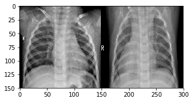

```
No Pneumonia Vs Pneumonia
---------------------------------------------------------------------------------------------------------------
```

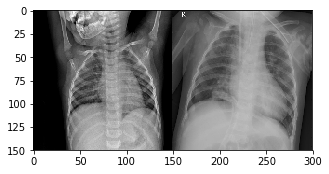

```
No Pneumonia Vs Pneumonia
---------------------------------------------------------------------------------------------------------------
```

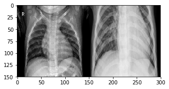

```
No Pneumonia Vs Pneumonia
---------------------------------------------------------------------------------------------------------------
```

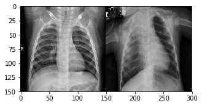

```
No Pneumonia Vs Pneumonia
---------------------------------------------------------------------------------------------------------------
```

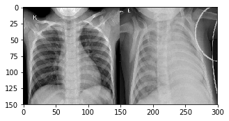

```python
for i in range(4,9):
    plotter(i)
```

```
Text(0.5,1,'Plot of the number of samples of each class in the training set')
```

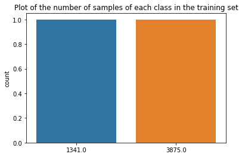

```python
import seaborn as sns
count = y_train.sum(axis = 0)
sns.countplot(x = count)
plt.title("Plot of the number of samples of each class in the training set")
```

```
Text(0.5,1,'Plot of the number of samples of each class in the test set')
```

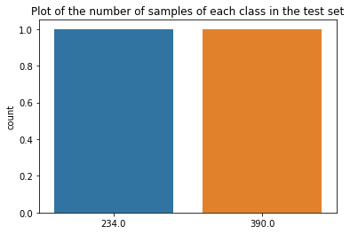

```python
count = y_test.sum(axis = 0)
sns.countplot(x = count)
plt.title("Plot of the number of samples of each class in the test set")
```

### Inference from the visualization above

As the data is imbalanced, the number of samples of both the classes do not match, hence accuracy is not a good metric to check for the robustness of the model

Therefore the evaluation of the model can be best done by using the confusion matrix.

- Here using the confusion matrix, we can infer from metrics like
  - Precision: What proportion of positive identifications was actually correct?
  - Recall: What proportion of actual positives was identified correctly?

Considering the context of the problem we are solving, **recall** is the metric we need to take care of.

### Deep Learning Code

```python
from keras.callbacks import ReduceLROnPlateau , ModelCheckpoint
lr_reduce = ReduceLROnPlateau(monitor='val_acc', factor=0.1, min_delta=0.0001, patience=1, verbose=1)
```

```python
filepath="weights_batchnorm_1.hdf5"
checkpoint = ModelCheckpoint(filepath, monitor='val_acc', verbose=1, save_best_only=True, mode='max')
```

```python
from keras.models import Sequential
from keras.layers import Dense , Activation
from keras.layers import Dropout
from keras.layers import Flatten
from keras.constraints import maxnorm
from keras.optimizers import SGD , RMSprop
from keras.layers import Conv2D , BatchNormalization
from keras.layers import MaxPooling2D
from keras.utils import np_utils
from keras import backend as K
K.set_image_dim_ordering('th')
from sklearn.model_selection import GridSearchCV
from keras.wrappers.scikit_learn import KerasClassifier
```

```python
X_train=X_train.reshape(5216,3,150,150)
X_test=X_test.reshape(624,3,150,150)
```

#### Normalize the data

```python
X_train = X_train/255.0
X_test = X_test/255.0
```

#### CNN architecture

```python
def swish_activation(x):
    return (K.sigmoid(x) * x)

model = Sequential()
model.add(Conv2D(16, (3, 3), activation='relu', padding="same", input_shape=(3,150,150)))
model.add(Conv2D(16, (3, 3), padding="same", activation='relu'))
model.add(MaxPooling2D(pool_size=(2, 2)))

model.add(Conv2D(32, (3, 3), activation='relu', padding="same", input_shape=(3,150,150)))
model.add(Conv2D(32, (3, 3), padding="same", activation='relu'))
model.add(MaxPooling2D(pool_size=(2, 2)))

model.add(Conv2D(64, (3, 3), activation='relu', padding="same"))
model.add(Conv2D(64, (3, 3), padding="same", activation='relu'))
model.add(MaxPooling2D(pool_size=(2, 2)))

model.add(Conv2D(96, (3, 3), dilation_rate=(2, 2), activation='relu', padding="same"))
model.add(Conv2D(96, (3, 3), padding="valid", activation='relu'))
model.add(MaxPooling2D(pool_size=(2, 2)))

model.add(Conv2D(128, (3, 3), dilation_rate=(2, 2), activation='relu', padding="same"))
model.add(Conv2D(128, (3, 3), padding="valid", activation='relu'))
model.add(MaxPooling2D(pool_size=(2, 2)))

model.add(Flatten())

model.add(Dense(64, activation=swish_activation))
model.add(BatchNormalization())
model.add(Dense(2 , activation='sigmoid'))

model.compile(loss='binary_crossentropy',
                  optimizer=RMSprop(lr=0.00008),
                  metrics=['accuracy'])

print(model.summary())
```

```
_________________________________________________________________
Layer (type)                 Output Shape              Param #
=================================================================
conv2d_111 (Conv2D)          (None, 16, 150, 150)      448
_________________________________________________________________
conv2d_112 (Conv2D)          (None, 16, 150, 150)      2320
_________________________________________________________________
max_pooling2d_56 (MaxPooling (None, 16, 75, 75)        0
_________________________________________________________________
conv2d_113 (Conv2D)          (None, 32, 75, 75)        4640
_________________________________________________________________
conv2d_114 (Conv2D)          (None, 32, 75, 75)        9248
_________________________________________________________________
max_pooling2d_57 (MaxPooling (None, 32, 37, 37)        0
_________________________________________________________________
conv2d_115 (Conv2D)          (None, 64, 37, 37)        18496
_________________________________________________________________
conv2d_116 (Conv2D)          (None, 64, 37, 37)        36928
_________________________________________________________________
max_pooling2d_58 (MaxPooling (None, 64, 18, 18)        0
_________________________________________________________________
conv2d_117 (Conv2D)          (None, 96, 18, 18)        55392
_________________________________________________________________
conv2d_118 (Conv2D)          (None, 96, 16, 16)        83040
_________________________________________________________________
max_pooling2d_59 (MaxPooling (None, 96, 8, 8)          0
_________________________________________________________________
conv2d_119 (Conv2D)          (None, 128, 8, 8)         110720
_________________________________________________________________
conv2d_120 (Conv2D)          (None, 128, 6, 6)         147584
_________________________________________________________________
max_pooling2d_60 (MaxPooling (None, 128, 3, 3)         0
_________________________________________________________________
flatten_12 (Flatten)         (None, 1152)              0
_________________________________________________________________
dense_23 (Dense)             (None, 64)                73792
_________________________________________________________________
batch_normalization_3 (Batch (None, 64)                256
_________________________________________________________________
dense_24 (Dense)             (None, 2)                 130
=================================================================
Total params: 542,994
Trainable params: 542,866
Non-trainable params: 128
_________________________________________________________________
None
```

```python
batch_size = 1
epochs = 25

import gc
gc.collect()
```

```
11895
```

```python
history = model.fit(X_train, y_train, validation_data = (X_test , y_test) ,callbacks=[lr_reduce,checkpoint] ,
          epochs=epochs)
```

```
Train on 5216 samples, validate on 624 samples

Epoch 00001: val_acc improved from -inf to 0.78205, saving model to weights_batchnorm_1.hdf5

Epoch 00002: ReduceLROnPlateau reducing learning rate to 7.999999797903002e-06.

Epoch 00002: val_acc did not improve from 0.78205

Epoch 00003: ReduceLROnPlateau reducing learning rate to 7.999999979801942e-07.

Epoch 00003: val_acc did not improve from 0.78205

Epoch 00004: val_acc improved from 0.78205 to 0.80929, saving model to weights_batchnorm_1.hdf5

Epoch 00005: val_acc improved from 0.80929 to 0.81090, saving model to weights_batchnorm_1.hdf5

Epoch 00006: val_acc improved from 0.81090 to 0.81490, saving model to weights_batchnorm_1.hdf5

Epoch 00007: ReduceLROnPlateau reducing learning rate to 8.00000009348878e-08.

Epoch 00007: val_acc did not improve from 0.81490

Epoch 00008: ReduceLROnPlateau reducing learning rate to 7.999999951380233e-09.

Epoch 00008: val_acc did not improve from 0.81490

Epoch 00009: ReduceLROnPlateau reducing learning rate to 7.999999773744548e-10.

Epoch 00009: val_acc did not improve from 0.81490

Epoch 00010: ReduceLROnPlateau reducing learning rate to 7.999999551699944e-11.

Epoch 00010: val_acc did not improve from 0.81490

Epoch 00011: ReduceLROnPlateau reducing learning rate to 7.999999274144188e-12.

Epoch 00011: val_acc did not improve from 0.81490

Epoch 00012: ReduceLROnPlateau reducing learning rate to 7.99999910067184e-13.

```

[output cut: 38 more lines]

```
Epoch 00022: ReduceLROnPlateau reducing learning rate to 7.999999746124181e-23.

Epoch 00022: val_acc did not improve from 0.81490

Epoch 00023: ReduceLROnPlateau reducing learning rate to 7.99999999855967e-24.

Epoch 00023: val_acc did not improve from 0.81490

Epoch 00024: ReduceLROnPlateau reducing learning rate to 8.000000156331851e-25.

Epoch 00024: val_acc did not improve from 0.81490

Epoch 00025: ReduceLROnPlateau reducing learning rate to 8.000000156331851e-26.

Epoch 00025: val_acc did not improve from 0.81490
```

### Model statistics

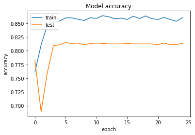

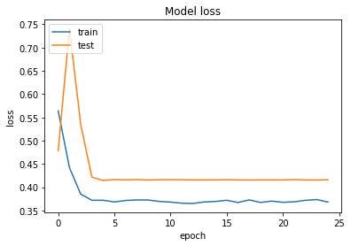

```python
plt.plot(history.history['acc'])
plt.plot(history.history['val_acc'])
plt.title('Model accuracy')
plt.ylabel('accuracy')
plt.xlabel('epoch')
plt.legend(['train', 'test'], loc='upper left')
plt.show()
plt.plot(history.history['loss'])
plt.plot(history.history['val_loss'])
plt.title('Model loss')
plt.ylabel('loss')
plt.xlabel('epoch')
plt.legend(['train', 'test'], loc='upper left')
plt.show()
```

```python
from sklearn.metrics import confusion_matrix
pred = model.predict(X_test)
pred = np.argmax(pred,axis = 1)
y_true = np.argmax(y_test,axis = 1)
```

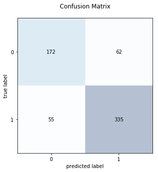

```python
CM = confusion_matrix(y_true, pred)
from mlxtend.plotting import plot_confusion_matrix
fig, ax = plot_confusion_matrix(conf_mat=CM ,  figsize=(5, 5))
plt.title("Confusion Matrix")
plt.show()
```

```python
def get_metric(cm):
    tn, fp, fn, tp = cm.ravel()
    precision = float(tp)/(tp+fp)
    recall = float(tp)/(tp+fn)
    return precision, recall

precision, recall = get_metric(cm)
print("Recall of the model is {:.2f}".format(recall))
print("Precision of the model is {:.2f}".format(precision))
f1_score = 2*(precision*recall)/precision+recall
print("F1 score of the model is {:.2f}".format(f1_score))
```

[output not shown]